# Untitled

## Total number of steps

### First, we download the dataset, unzip it and make the dataframe of it.

```r
library (ggplot2)
URL<-"https://d396qusza40orc.cloudfront.net/repdata%2Fdata%2Factivity.zip"
    dir<-paste(getwd(),"/a.zip",sep="")#get url
    download.file(URL,dir)#upload file
    unzip(dir)#unzip file
    Frame<-read.csv("activity.csv")
    Frame$date<-as.POSIXct(Frame$date)
```

### Then we plot the number of steps by date.

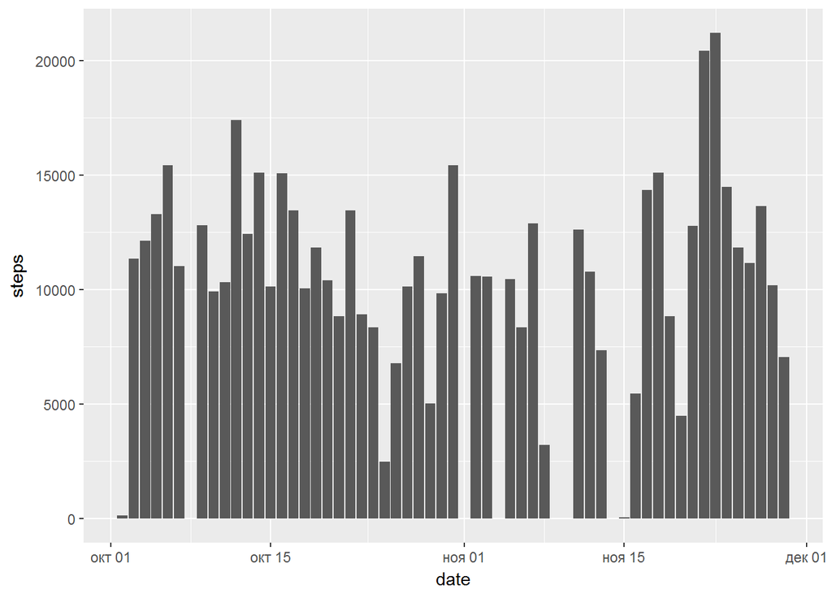

```r
C0<-aggregate(steps~date,data=Frame,FUN=sum)
    C0$date<-as.POSIXct(C0$date)
    ggplot(C0,aes(x=date,y=steps))+ geom_bar(stat="identity")
```

## Mean number of steps

We also plot the mean number of steps.

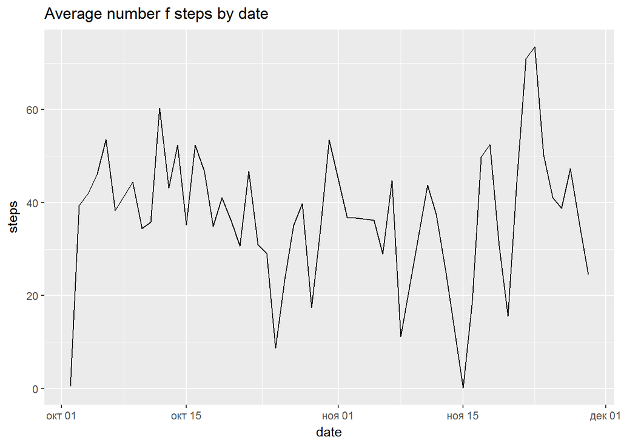

```r
C1<-aggregate(steps~date,data=Frame,FUN=mean)
    C1$date<-as.POSIXct(C1$date)
    ggplot(C1,aes(x=date,y=steps))+ geom_line()+ggtitle("Average number f steps by date")
```

## Median number of steps

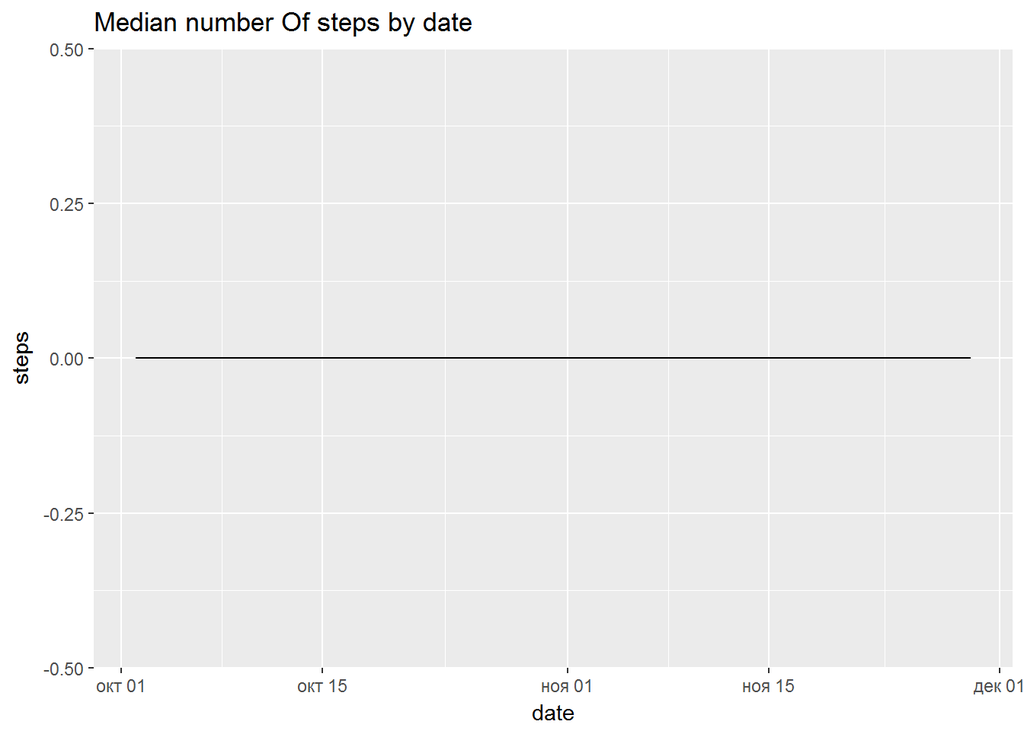

```r
C2<-aggregate(steps~date,data=Frame,FUN=median)
    C2$date<-as.POSIXct(C2$date)
    ggplot(C2,aes(x=date,y=steps))+ geom_line()+ggtitle("Median number Of steps by date")
```

## Average number of steps

We also plot average number of steps taken by interval

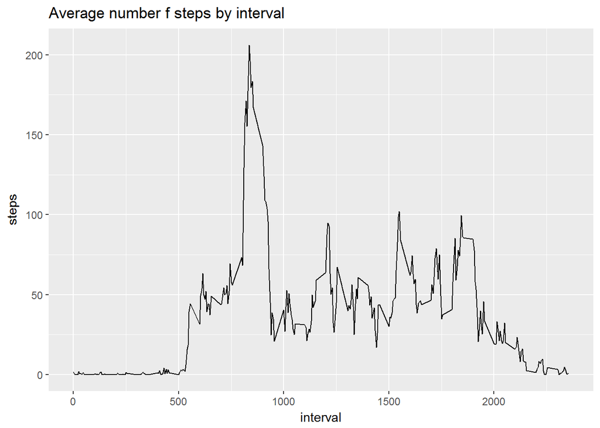

```r
C4<-aggregate(steps~interval,data=Frame,FUN=mean)
#plot average by INTERVAL
ggplot(C4,aes(x=interval,y=steps))+ geom_line()+ggtitle("Average number f steps by interval")
```

## Maximal number of steps

We also find the 5minute interval where the number of steps is the largest

```r
Frame$date<-as.POSIXct(Frame$date)
d<-which.max(Frame[,1])
C<-c(as.character(Frame[d,2]), as.character(Frame[d,3]/100))
C
```

```
## [1] "2012-11-27" "6.15"
```

## Imputing missing values

Number of missing values is

```r
sum(is.na(Frame$steps))
```

```
## [1] 2304
```

### Missing values are imputed by placing the median by the interval where NA was found instead of NA.

```r
Frame2<-Frame
Frame2$date<-as.POSIXct(Frame2$date)
Frame1<-aggregate(steps~interval,data=Frame2,FUN=median,na.rm=TRUE)#median by time
for(i in 1:dim(Frame2)[1])
{
  if(is.na(Frame2$steps[i]))
  {
   Frame2$steps[i]<-Frame1$steps[which(Frame2$interval[i]==Frame1$interval)][1]
  }
}
C0<-aggregate(steps~date,data=Frame2,FUN=sum)
```

## Total number of steps taken each day

The histogram of the total number of steps per day was made. Mean and median number of steps are also displayed above

[figure not shown]

```r
ggplot(C0,aes(x=date,y=steps))+ geom_bar(stat="identity")+ggtitle("Total number of steps taken each day")+geom_hline(aes(yintercept=median(C0$steps,na.rm=TRUE), linetype="Median"), color = "blue",show.legend= TRUE)+geom_hline(aes(yintercept=mean(C0$steps,na.rm=TRUE), linetype="Mean"), color = "red",show.legend= TRUE) +scale_linetype_manual(name = "number of steps", values = c(2, 2),
guide = guide_legend(override.aes = list(color = c("blue", "red"))))
```

Median number of steps taken each day is

```r
median(C0$steps,na.rm=TRUE)
```

```
## [1] 10395
```

Mean number of steps taken per day is

```r
mean(C0$steps,na.rm=TRUE)
```

```
## [1] 9503.869
```

## Weekday and weekend patterns

All the days were identified as either weekdays or weekends. Dataframe was split and divided by 2 groups - weekends and weekdays.Then these data were plotted

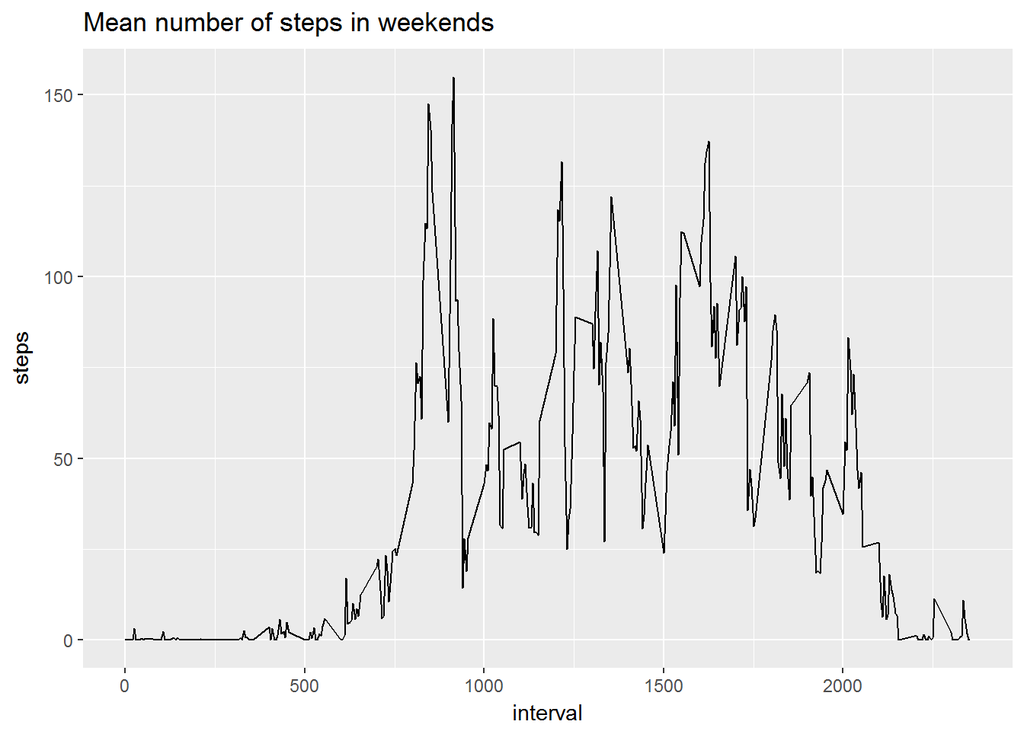

```r
Frame2$weekday<-rep("weekday",dim(Frame2)[1])
invisible( Sys.setlocale("LC_ALL","English"))
for (i in (1:dim(Frame2)[1]))
{
  if((weekdays(Frame2$date[i])=="Sunday")|(weekdays(Frame2$date[i])=="Saturday"))
  {
    Frame2$weekday[i]="weekend"
  }
}
Frame2$weekday<-as.factor(Frame2$weekday)
Frame3<-split(Frame2,Frame2$weekday)

##split надо корректно
Weekend<-aggregate(steps~interval,data=Frame3$weekend,FUN=mean,na.rm=TRUE)

Weekday<-aggregate(steps~interval,data=Frame3$weekday,FUN=mean,na.rm=TRUE)
ggplot(Weekend,aes(x=interval,y=steps))+ geom_line()+ggtitle ("Mean number of steps in weekends")
```

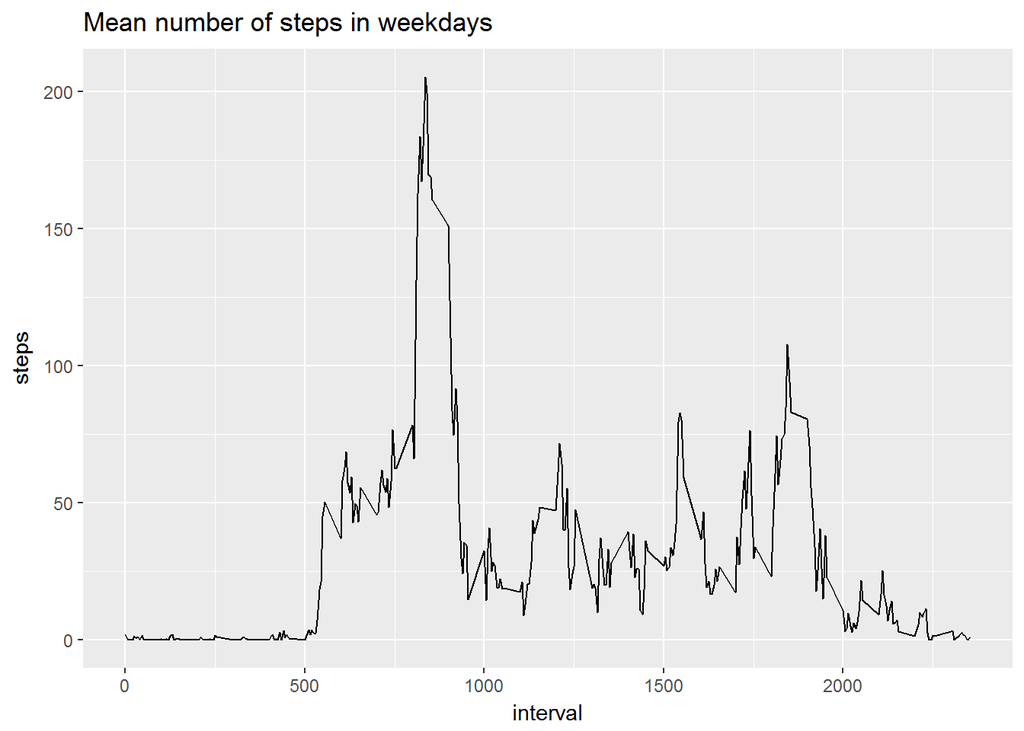

```r
ggplot(Weekday,aes(x=interval,y=steps))+ geom_line()+ggtitle ("Mean number of steps in weekdays")
```